# Project1

Cassie, Caleb, & Mike

Monday, February 02, 2015

**In this project, we will document and explain the steps taken in order to take data from a database and make interesting graphs.**

First, we need to load the libraries “RCurl”, used for processing HTTP requests, and “reshape2”, used to restructure data.

Next, we call the customers table, found using the query:

```
select * from customers
```

Once we have assigned the customers table data to the `dfc` dataframe, we can view the first few rows by calling the function:

```
print(head(dfc))
```

These steps are shown below.

```r
#source("../01 Data/dataframes.R", echo = TRUE)

source("../01 Data/dfc.R", echo = TRUE)
```

```
##
## > library("RCurl")
```

```
##
## > library("reshape2")
##
## > dfc <<- data.frame(eval(parse(text = substring(getURL(URLencode("http://129.152.144.84:5001/rest/native/?query=\"select * from customers\""),
## +     .... [TRUNCATED]
##
## > print(head(dfc))
##   CUSTOMER_ID CUSTOMER_FIRST_NAME CUSTOMER_LAST_NAME      CUSTOMER_ADDRESS
## 1           1               Korah             Blanca       1555 W Lane Ave
## 2           2                Yash            Randall 11 E Rancho Madera Rd
## 3           3           Johnathon          Millerton        60 Madison Ave
## 4           4             Mikayla             Damion      2021 K Street Nw
## 5           5             Kendall              Mayte 4775 E Miami River Rd
## 6           6             Kaitlin           Hostlery 3250 Spring Grove Ave
##   CUSTOMER_CITY CUSTOMER_STATE CUSTOMER_ZIP CUSTOMER_PHONE CUSTOMER_FAX
## 1      Columbus             OH        43221     6145554432   6145553920
## 2       Madison             WI        53707     2095551205   2095552262
## 3      New York             NY        10010     2125554800         NULL
## 4    Washington             DC        20006     2025555561         NULL
## 5        Cleves             OH        45002     5135553024         NULL
## 6    Cincinnati             OH        45225     8005552128   8005552640
```

**Now, let’s do something fun with the data.** First, we need to load the “ggplot2” library, which is a plotting system for R.

As we can see, there are many columns to this database: `CUSTOMER_ID`, `CUSTOMER_FIRST_NAME`, `CUSTOMER_LAST_NAME`, …

Let’s make a plot of this data that displays the area code versus city for each customer, coloring each point by state. It’s not a particularly useful graph, but it conveys the ability of R to readily display certain data in a graphical format.

Note that the `ggplot()` function accepts the dataframe as its first argument, followed by the `aes()` function as its second argument to define aesthetics of the graph area.

The call to make a scatterplot is:

```
geom_point(mapping = NULL, data = NULL, stat = "identity", position = "identity", na.rm = FALSE, ...)
```

This function is added to the `ggplot()` function call to define the graph as a scatterplot.

The R code that creates this graph is shown below.

```
##
## > library("ggplot2")
##
## > ggplot(dfc, aes(x = as.integer(substr(CUSTOMER_PHONE,
## +     0, 3)), y = CUSTOMER_CITY, color = CUSTOMER_STATE)) + geom_point()
```

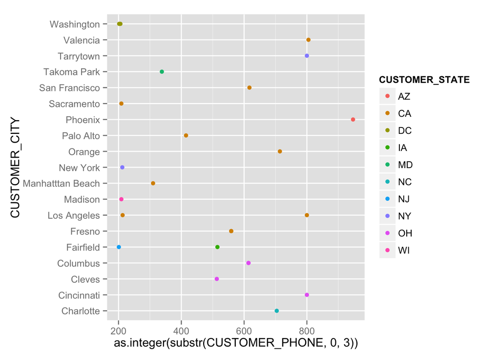

```r
source("../02 Visualizations/dfcplot.R", echo = TRUE)
```

Next, we’ll make a dataframe from the order_details table, using the query:

```
select * from order_details
```

```r
source("../01 Data/dfd.R", echo = TRUE)
```

```
##
## > dfd <<- data.frame(eval(parse(text = substring(getURL(URLencode("http://129.152.144.84:5001/rest/native/?query=\"select * from order_details\""),
## + .... [TRUNCATED]
##
## > print(head(dfd))
##   ORDER_ID ITEM_ID ORDER_QTY
## 1      381       1         1
## 2      601       9         1
## 3      442       1         1
## 4      523       9         1
## 5      630       5         1
## 6      778       1         1
```

This just has the columns `ORDER_ID`, `ITEM_ID`, and `ORDER_QTY` - not particularly exciting. Also, all but two of the `ORDER_QTY` rows are equal to 1. So, let’s add some qualifiers to our search query to spice this data up:

```
select ITEM_ID, sum(ORDER_QTY) Total_Quantity from order_details group by ITEM_ID order by ITEM_ID
```

Here, we have ignored the `ORDER_ID` column and instead grouped the data by the `ITEM_ID`, with the corresponding value equal to the total number of orders for each item - `sum(ORDER_QTY)`.

```r
source("../01 Data/dfdSum.R", echo = TRUE)
```

```
##
## > dfdSum <<- data.frame(eval(parse(text = substring(getURL(URLencode("http://129.152.144.84:5001/rest/native/?query=\"select ITEM_ID, sum(ORDER_QTY) T .... [TRUNCATED]
##
## > print(head(dfdSum))
##   ITEM_ID TOTAL_QUANTITY
## 1       1             13
## 2       2              4
## 3       3              8
## 4       4              8
## 5       5              6
## 6       6              7
```

Now that we have the data grouped and ordered by item, we can make a bar graph showing the total quantity purchased of each item. The call to make a bar graph is:

```
geom_bar(mapping = NULL, data = NULL, stat = "bin", position = "stack", ...)
```

```
##
## > ggplot(dfdSum, aes(x = as.factor(ITEM_ID), y = TOTAL_QUANTITY)) +
## +     geom_bar(color = "Black", fill = "#00FF00", stat = "identity")
```

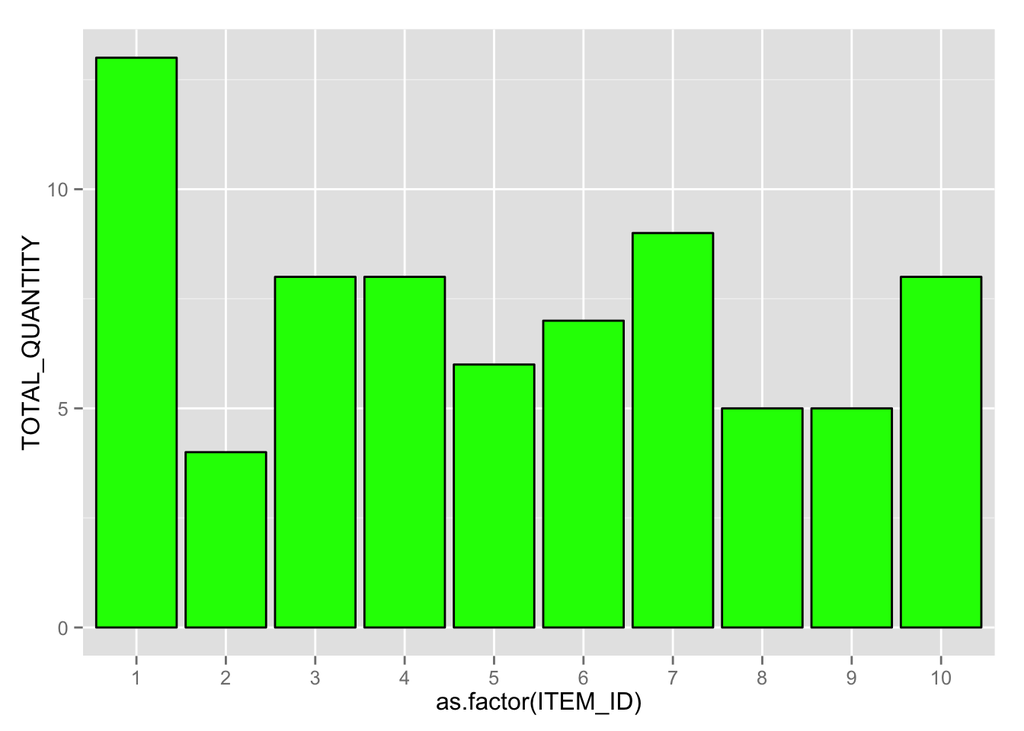

```r
source("../02 Visualizations/dfdSumplot.R", echo = TRUE)
```

Moving on to the orders table, we set the search query to:

```
select * from orders
```

We can see that the columns are `ORDER_ID`, `CUSTOMER_ID`, `ORDER_DATE`, and `SHIPPED_DATE`.

```r
source("../01 Data/dfo.R", echo = TRUE)
```

```
##
## > dfo <<- data.frame(eval(parse(text = substring(getURL(URLencode("http://129.152.144.84:5001/rest/native/?query=\"select * from orders\""),
## +     ht .... [TRUNCATED]
##
## > print(head(dfo))
##   ORDER_ID CUSTOMER_ID          ORDER_DATE        SHIPPED_DATE
## 1       19           1 2012-10-23 00:00:00 2012-10-28 00:00:00
## 2       29           8 2012-11-05 00:00:00 2012-11-11 00:00:00
## 3       32          11 2012-11-10 00:00:00 2012-11-13 00:00:00
## 4       45           2 2012-11-25 00:00:00 2012-11-30 00:00:00
## 5       70          10 2012-12-28 00:00:00 2013-01-07 00:00:00
## 6       89          22 2013-01-20 00:00:00 2013-01-22 00:00:00
```

From this data, we can make a scatterplot showing the `ORDER_ID` versus the `CUSTOMER_ID`, with the color of each point representative of the `CUSTOMER_ID`. The `as.factor()` function separates the colors into distinct groups, as shown in the legend to the right of the graph. Without this function, the colors would follow a gradient along the domain of `CUSTOMER_ID`.

```
##
## > ggplot(dfo, aes(x = CUSTOMER_ID, y = ORDER_ID, color = as.factor(CUSTOMER_ID))) +
## +     geom_point()
```

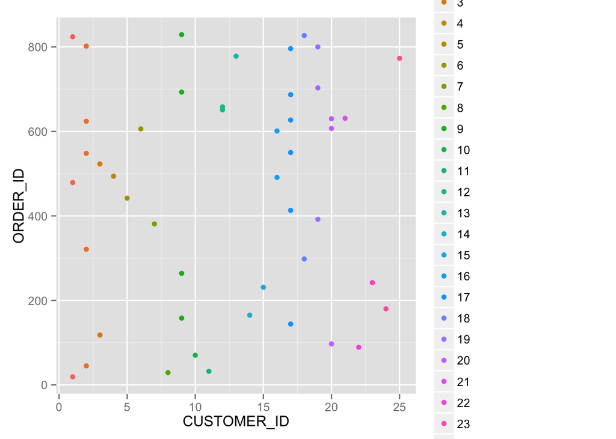

```r
source("../02 Visualizations/dfoplot.R", echo = TRUE)
```

Similarly, the search query for the items table is:

```
select * from items
```

This table has the columns `ITEM_ID`, `TITLE`, `ARTIST`, and `UNIT_PRICE`.

```r
source("../01 Data/dfi.R", echo = TRUE)
```

```
##
## > dfi <<- data.frame(eval(parse(text = substring(getURL(URLencode("http://129.152.144.84:5001/rest/native/?query=\"select * from items\""),
## +     htt .... [TRUNCATED]
##
## > print(head(dfi))
##   ITEM_ID                                       TITLE
## 1       1                            Umami In Concert
## 2       2                             Race Car Sounds
## 3       3                       No Rest For The Weary
## 4       4 More Songs About Structures and Comestibles
## 5       5               On The Road With Burt Ruggles
## 6       6                            No Fixed Address
##                  ARTIST UNIT_PRICE
## 1                 Umami         17
## 2         The Ubernerds         13
## 3 No Rest For The Weary         16
## 4 No Rest For The Weary         17
## 5          Burt Ruggles         17
## 6 Sewed the Vest Pocket         16
```

Now, we’ll make a scatterplot of the data: `UNIT_PRICE` versus `ARTIST`.

```
##
## > ggplot(dfi, aes(x = ARTIST, y = UNIT_PRICE, color = ARTIST)) +
## +     geom_point()
```

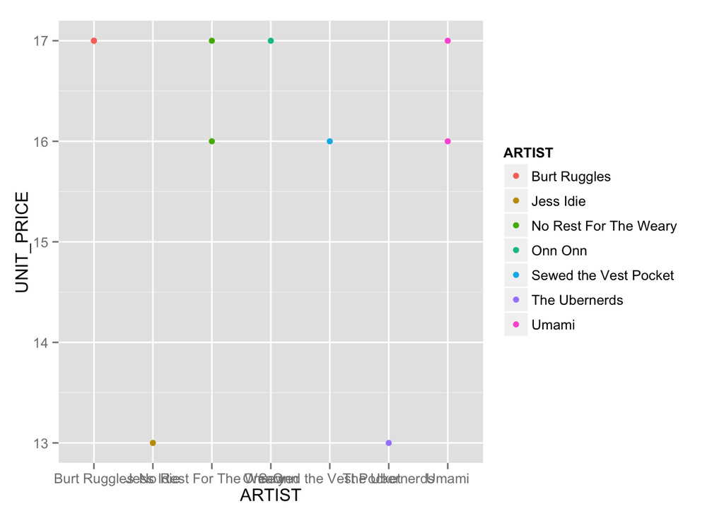

```r
source("../02 Visualizations/dfiplot.R", echo = TRUE)
```

Let’s find a way to aggregate the data from all four tables and make a graph that reveals something about the entire data set.

We’ll use the search query:

```
select * from orders o join customers c on o.customer_id = c.customer_id join order_details d on o.order_id = d.order_id join items i on d.item_id = i.item_id
```

In this query, we can see that there is the typical “select all” call in the form of `select * from orders`. This is followed by three `join` clauses, which define how to connect the tables together. For instance, `o.customer_id = c.customer_id` joins the tables by connecting the customer ID from each table and adding the other corresponding values to each row. The same technique joins the order ID from the order_details table, and the item ID from the items table.

```r
source("../01 Data/dfm.R", echo = TRUE)
```

```
##
## > dfm <<- data.frame(eval(parse(text = substring(getURL(URLencode("http://129.152.144.84:5001/rest/native/?query=\"select * from orders o join custome .... [TRUNCATED]
##
## > print(head(dfm))
##   ORDER_ID CUSTOMER_ID          ORDER_DATE        SHIPPED_DATE
## 1      550          17 2014-03-23 00:00:00 2014-04-03 00:00:00
## 2      298          18 2013-08-18 00:00:00 2013-09-22 00:00:00
## 3      242          23 2013-06-24 00:00:00 2013-07-06 00:00:00
## 4      829           9 2014-08-02 00:00:00                null
## 5       70          10 2012-12-28 00:00:00 2013-01-07 00:00:00
## 6      800          19 2014-07-21 00:00:00 2014-07-28 00:00:00
##   CUSTOMER_ID.1 CUSTOMER_FIRST_NAME CUSTOMER_LAST_NAME
## 1            17              Samuel           Jacobsen
## 2            18              Justin              Javen
## 3            23              Trisha               Anum
```

[output cut: 24 more lines]

Finally, lets plot the `SHIPPED_DATE` versus the `ORDER_DATE` for the orders, separating the scatterplots by `CUSTOMER_STATE`. To separate the graphical area into separate plots for each state, use the `facet_wrap()` function with the customer state as the argument.

The `as.Date()` function allows the user to specify the formatting of each date as it appears on each axis.

We’ll create this graph three times, using `UNIT_PRICE`, `TITLE`, and `ARTIST` as the color variables, respectively.

```
##
## > ggplot(dfm, aes(x = as.Date(ORDER_DATE, "%Y-%m-%d"),
## +     y = as.Date(SHIPPED_DATE, "%Y-%m-%d"), color = as.factor(UNIT_PRICE))) +
## +     geom_poi .... [TRUNCATED]
```

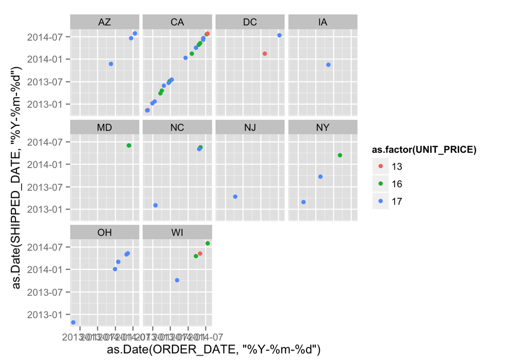

```
##
## > ggplot(dfm, aes(x = as.Date(ORDER_DATE, "%Y-%m-%d"),
## +     y = as.Date(SHIPPED_DATE, "%Y-%m-%d"), color = as.factor(TITLE))) +
## +     geom_point()  .... [TRUNCATED]
```

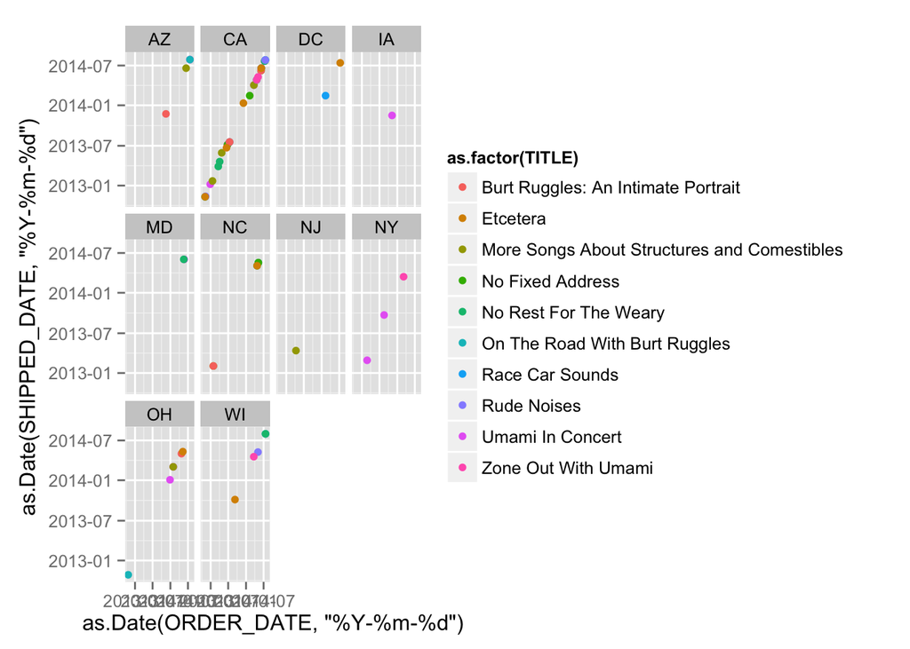

```
##
## > ggplot(dfm, aes(x = as.Date(ORDER_DATE, "%Y-%m-%d"),
## +     y = as.Date(SHIPPED_DATE, "%Y-%m-%d"), color = as.factor(ARTIST))) +
## +     geom_point() .... [TRUNCATED]
```

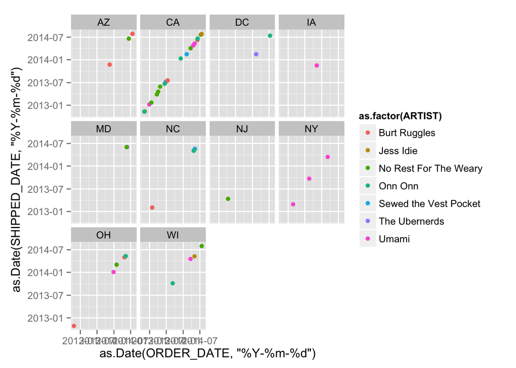

```r
source("../02 Visualizations/dfmplot.R", echo = TRUE)
```

```r
#library("ggplot2")
#library("reshape2")

#source("../02 Visualizations/Graphs.R", echo = TRUE)
```